# Analysing Video Game Sales Figures

Joe Friel & Dylan Weaver

5/15/2019

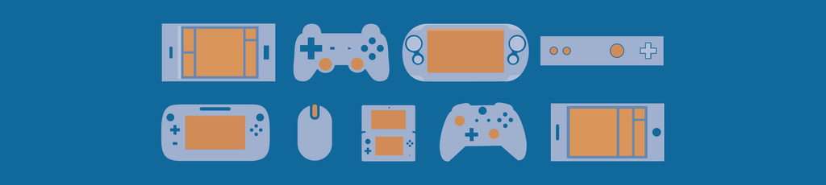

# Motivation

The video game industry is huge, and filled with sensational headlines in the news, so it is often hard to get a good grasp of what’s really going on. We want to get past the headlines and look at objective data in order to learn more about game sales and ratings.

This data could also be useful for game companies and developers to see exactly what games sell well and on what consoles. Profits are surely what drive these companies, and this tutorial would help guide those kinds of decisions.

Another motivation for this project is that we both enjoy video games and want to learn more about the data behind them.

# Background on Data

This data in this dataset contains video games released between 1980 and 2016. Both the critic and user scores were both taken directly from [Metacritic](https://www.metacritic.com/).

# The Problem We’re Answering

For this project, We will be analyzing video games and their sales figures as well as ratings. The purpose of this project is to see the correlation, if any, between platform, genre, sales, and rating.

Our null hypothesis is that there is no effect between any 3 of {platform, genre, sales} and rating.

To do this, we’re going to take our dataset and clean up anything that will affect our analysis. Next, we will create a variety of visualizations to help better understand the trends that appear in the data. We will then use hypothesis testing to test the claims that we will make.

# Loading Libraries

Before we start loading and processing our data, we’re going to load various libraries that will help us perform our analysis

```r
library(tidyverse)
library(reshape2) # To help us make cool plots :)
library(rbokeh) # Instead of ggplot2
library(broom) # To help us interpret the results of our linear models
```

# Data Collection

We’re going to start by simply loading the CSV file into a variable named `data`.

```r
data <- read_csv("Video_Game_Sales.csv")
```

Now that we’ve loaded in the data, it’s a good idea to take a loot at a sample of it to get an idea of what we will be working with.

```r
# View a random selection of entities from out dataset
data %>%
  sample_n(10) %>% # Randomly select 10 entities
  head()
```

```
## # A tibble: 6 x 16
##   Name  Platform Year_of_Release Genre Publisher NA_Sales EU_Sales JP_Sales
##   <chr> <chr>    <chr>           <chr> <chr>        <dbl>    <dbl>    <dbl>
## 1 Trea~ DS       2011            Adve~ Namco Ba~     0        0        0.05
## 2 Mons~ X360     2007            Shoo~ SouthPea~     0.1      0        0
## 3 Rugb~ PS3      2015            Acti~ Tru Blu ~     0        0.01     0
## 4 Mach~ PS       1996            Shoo~ Eidos In~     0.04     0.03     0
## 5 Kanj~ DS       2006            Misc  Nintendo      0        0        0.07
## 6 Yosh~ GBA      2004            Plat~ Nintendo      0.25     0.09     0.3
## # ... with 8 more variables: Other_Sales <dbl>, Global_Sales <dbl>,
## #   Critic_Score <dbl>, Critic_Count <dbl>, User_Score <chr>,
## #   User_Count <dbl>, Developer <chr>, Rating <chr>
```

As you can see the entities are different video games each with their respective platform, release year, genre, publisher, developer, sales figures, and ratings. These attributes will allow us to perform comparisons about our data.

# Exploratory Data Analysis

Now that we know what our data looks like, we are going to vizualize it. We will begin by grouping our entities by console so we can see the breakdown of games by console.

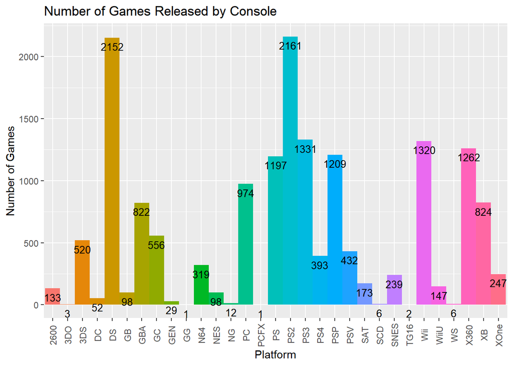

As is evident in the bar chart above, the data is numerous and will be hard to work with if we keep all of this data. Because of this, we are going to limit our analysis to only games since the year 2000. This is to reduce the number of consoles, games, and remove some outliers in our analysis.

```r
# A subset of our original data containing data for games released in 2000 or after
data2000 <- data %>%
  filter(Year_of_Release >= 2000)
```

In today’s video game scene there are 3 major console companies: Sony, Microsoft, and Nintendo, who produce the PlayStation consoles, the XBox consoles, and the Wii/Switch consoles respectively. By filtering the games using the year 2000 we can limit our analysis to these companies along with PC games.

With these restrictions, let’s view the same plot again:

```r
barplot2000 <- data2000 %>%
  group_by(Platform) %>%
  summarise(number = n()) %>%
  filter(number >= 100) %>% # We only want platforms that have more than 100 games
  ggplot(aes(x=Platform, y=number, fill = Platform)) +
  geom_bar(width = 1, stat = "identity") +
  labs(title = "Number of Games Released by Console Since 2000", x = "Platform", y = "Number of Games") +
  geom_text(aes(label=number), vjust=1.6, color="black", size=3.5) # Add labels to the bars indicating number of games +
  theme(legend.position='none') # We don't need a legend
```

```
## List of 1
##  $ legend.position: chr "none"
##  - attr(*, "class")= chr [1:2] "theme" "gg"
##  - attr(*, "complete")= logi FALSE
##  - attr(*, "validate")= logi TRUE
```

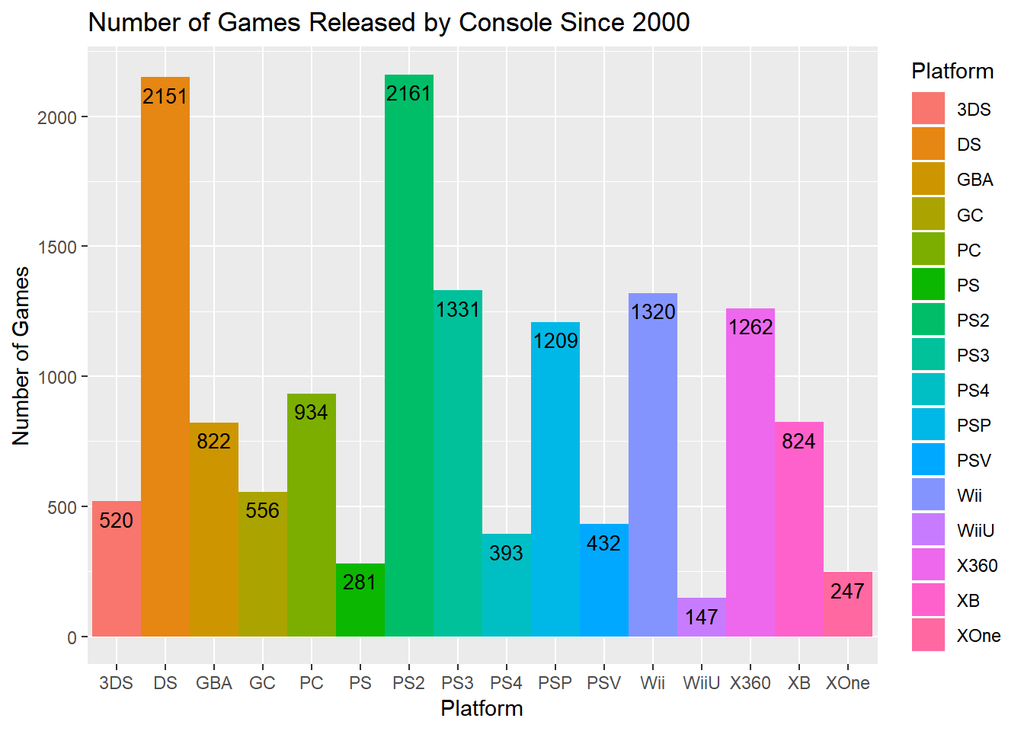

```r
barplot2000
```

This graph is much easier to handle and visualize, as there are far fewer consoles being shown. Only major consoles are left, which will benefit our analysis as there will be less outlier data involved that could impact our results.

There is some missing data that will affect our analysis. Let’s see some of that missing data.

```r
data2000 %>%
  filter(is.na(User_Score) | is.na(User_Count) | is.na(Critic_Score) | is.na(Critic_Count)) %>%
  select(Name, Year_of_Release, Genre, User_Score, User_Count, Critic_Score, Critic_Count) %>%
  sample_n(20)
```

```
## # A tibble: 20 x 7
##    Name  Year_of_Release Genre User_Score User_Count Critic_Score
##    <chr> <chr>           <chr> <chr>           <dbl>        <dbl>
##  1 Pro ~ 2011            Spor~ <NA>               NA           NA
##  2 Raym~ 2008            Misc  tbd                NA           NA
##  3 Ford~ 2005            Raci~ tbd                NA           NA
##  4 Kann~ 2012            Adve~ <NA>               NA           NA
##  5 Stei~ 2013            Adve~ <NA>               NA           NA
##  6 Mons~ 2008            Role~ tbd                NA           NA
##  7 NCAA~ 2008            Spor~ tbd                NA           68
##  8 Drak~ 2009            Role~ <NA>               NA           NA
##  9 Shin~ 2011            Acti~ <NA>               NA           NA
## 10 Grey~ 2009            Adve~ 7.5                 4           NA
## 11 Pac-~ 2005            Plat~ tbd                NA           44
## 12 My P~ 2008            Simu~ tbd                NA           60
## 13 Proj~ 2016            Role~ <NA>               NA           NA
## 14 SCOR~ 2008            Raci~ <NA>               NA           NA
## 15 Gree~ 2011            Acti~ tbd                NA           46
## 16 Fast~ 2010            Simu~ tbd                NA           NA
## 17 Grad~ 2001            Shoo~ tbd                NA           78
## 18 MX W~ 2005            Raci~ tbd                NA           51
## 19 Hall~ 2011            Adve~ <NA>               NA           NA
## 20 Godz~ 2014            Acti~ <NA>               NA           NA
## # ... with 1 more variable: Critic_Count <dbl>
```

It’s clear that the missing data is not missing systematically, but rather, missing at random. We are going to impute the averages of `User_Score`, `User_Count`, `Critic_Score`, and `Critic_Count` when we tidy our data in the next section

# Tidying Our Data

There are some things about our data that will present troubles later during our analysis. We’re going to fix them here so we don’t need to interrupt our analysis.

```r
# Firstly, some of our data has invalid attributes for our purposes. We simply filter that out
data2000 <- data2000 %>%
  filter(Year_of_Release != "N/A" | User_Score != "tbd")


# Make User_Score numeric (it's currently a character column)
data2000 <- data2000 %>%
  mutate(User_Score = as.double(User_Score))

# We multiply user score by 10 to fit in line with our critic scores
# Currently, User_Score is out of 10, and Critic_Score is out of 100
data2000 <- data2000 %>%
  mutate(User_Score = User_Score * 10.0)

# Next, we don't really care about the individual region sales, as there is a global sales attribute that we will use instead.
data2000 <- data2000 %>%
  subset(select = -c(NA_Sales, EU_Sales, JP_Sales, Other_Sales))

# We're going to impute the data so that any randomly missing data is replaced by an estimate of that game's genre on its console for its release year
# First we have to compute averages so that we have values to replace our missing data with
dataAverages <- data2000 %>%
  drop_na(Critic_Score) %>%
  drop_na(User_Score) %>%
  drop_na(Critic_Count) %>%
  drop_na(User_Count) %>%
  group_by(Genre, Platform, Year_of_Release) %>%
  summarize(meanUserScore = mean(User_Score),
            meanUserCount = mean(User_Count),
            meanCriticScore = mean(Critic_Score),
            meanCriticCount = mean(Critic_Count))

# Let's see some of the data
dataAverages %>%
  head()
```

```
## # A tibble: 6 x 7
## # Groups:   Genre, Platform [1]
##   Genre Platform Year_of_Release meanUserScore meanUserCount
##   <chr> <chr>    <chr>                   <dbl>         <dbl>
## 1 Acti~ 3DS      2011                     59.3          28.5
## 2 Acti~ 3DS      2012                     69.3         122.
## 3 Acti~ 3DS      2013                     70           204
## 4 Acti~ 3DS      2014                     58            48
## 5 Acti~ 3DS      2015                     68.8         155.
## 6 Acti~ 3DS      2016                     72            68.2
## # ... with 2 more variables: meanCriticScore <dbl>, meanCriticCount <dbl>
```

```r
# Merge out two dataframes based on the following attributes
data2000 <- data2000 %>%
  merge(dataAverages, by=c("Genre", "Platform", "Year_of_Release"))

# Here we are replacing any NA values with the average score for that game's genre on its platform for its year of release
data2000 <- data2000 %>%
   mutate(User_Score = ifelse(is.na(User_Score), meanUserScore, User_Score)) %>%
   mutate(Critic_Score = ifelse(is.na(Critic_Score), meanCriticScore, Critic_Score))
```

With our tidying complete, let’s once again look at a sample of the data.

```r
data2000 %>%
  sample_n(10)
```

```
##          Genre Platform Year_of_Release
## 275     Action       DS            2007
## 13506 Strategy     X360            2008
## 481     Action       DS            2011
## 135     Action      3DS            2015
## 2316    Action      Wii            2012
## 10136  Shooter     X360            2006
## 7791    Racing      Wii            2007
## 11923   Sports      PS2            2006
## 4051  Fighting       GC            2005
## 292     Action       DS            2007
##                                                                  Name
## 275                                                 The Simpsons Game
## 13506                                             Tom Clancy's EndWar
## 481                                            Kaijuu Busters Powered
```

[output cut: 40 more lines]

Let’s make some plots based on genre. We’ll start by comparing user scores against critic scores, as people often disagree with critic’s reviews of games.

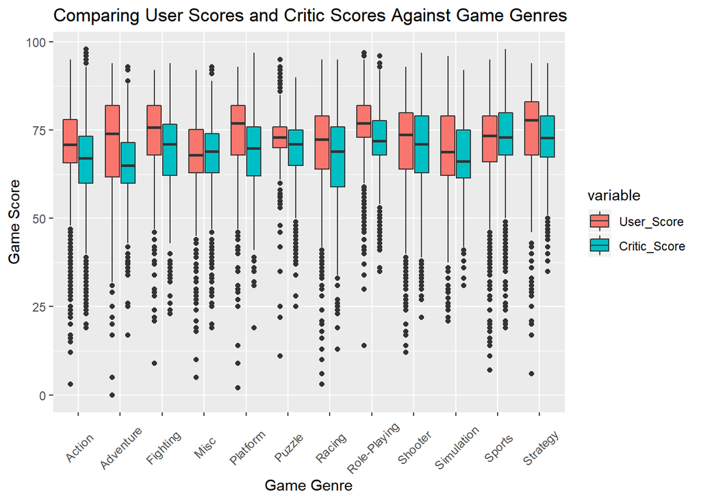

```r
# Transposes columns into rows allowing us to group by the kind of score we want to plot
data2000.m <- data2000 %>%
  melt(id.vars='Genre', measure.vars=c('User_Score', 'Critic_Score'))

data2000.m %>%
  ggplot(aes(x=Genre, y=as.numeric(value), fill = variable)) +
  geom_boxplot() +
  labs(title="Comparing User Scores and Critic Scores Against Game Genres", x="Game Genre", y="Game Score") +
  theme(axis.text.x = element_text(angle = 45, vjust = 0.5)) # Rotate the x-axis labels to make them easier to read
```

The `Reshape2` library helped us accomplish this easily with its `melt` function, which allows us to group by the user_score or critic_score for each game. You can read more about it here: https://seananderson.ca/2013/10/19/reshape/.

Looking at this plot, we can see that almost every genre of video games receives an average score of around 75. One interesting thing to note is that the worst `Critic_Score` in a particular genre are always higher than the worst `User_Score` in a genre.

A few `Action` Games received very close to a perfect (100) critic score. Let’s go ahead and look at what game that the top rated `Action` game is:

```r
data2000 %>%
  filter(Genre == 'Action') %>%
  arrange(desc(Critic_Score)) %>%
  head(1)
```

```
##    Genre Platform Year_of_Release                Name            Publisher
## 1 Action      PS3            2008 Grand Theft Auto IV Take-Two Interactive
##   Global_Sales Critic_Score Critic_Count User_Score User_Count
## 1         10.5           98           64         75       2833
##        Developer Rating meanUserScore meanUserCount meanCriticScore
## 1 Rockstar North      M            71      298.2333        68.63333
##   meanCriticCount
## 1        37.93333
```

We’re going to look at the top 25 games based on sales. To accomplish we’re going to create a new dataframe, where we take every game and sum the sales across all platforms. This will be useful because a game like Grand Theft Auto v sold much differently across many platforms, all of which should be accounted for.

```r
# Get the total sum of sales for a game across all platforms
# e.g. Grand Theft Auto V for {360, PS3, XBOne, PS4, PC}
data_sales <- data2000 %>%
  group_by(Name) %>%
  summarize(total_sales = sum(Global_Sales))

data_sales %>%
  arrange(desc(total_sales)) %>%
  head()
```

```
## # A tibble: 6 x 2
##   Name                           total_sales
##   <chr>                                <dbl>
## 1 Wii Sports                            82.5
## 2 Grand Theft Auto V                    56.6
## 3 Mario Kart Wii                        35.5
## 4 Wii Sports Resort                     32.8
## 5 Call of Duty: Black Ops               30.8
## 6 Call of Duty: Modern Warfare 3        30.6
```

Now that we know what our data looks like, let’s visualize the top 25 games by sales:

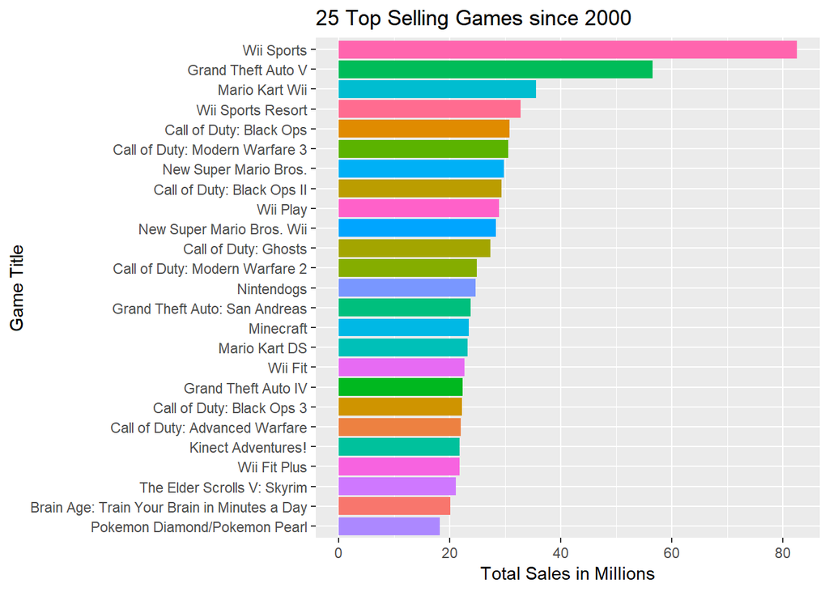

```r
# Now let's look at a bar plot of the top 25 games as rated by critics:
data_sales %>%
  arrange(desc(total_sales)) %>%
  slice(1:25) %>% # We only want the top 25 best selling games
  ggplot(aes(x=reorder(Name,total_sales), y=total_sales, fill=Name)) +
  geom_bar(stat='identity') +
  labs(title="25 Top Selling Games since 2000", x="Game Title", y="Total Sales in Millions") +
  coord_flip() + # Make it a horizontal bar plot!
  theme(legend.position='none') # We don't need a legend, it would take up too much space
```

From the graph above, we see that `Wii Sports` is the best selling game since 2000 in our dataset. It sold over 80 million copies! The next best selling game is `Grand Theft Auto V`, which has just around 57 million copies sold. Why is `Wii Sports` such a top selling game? The answer is that it was bundled with every Wii console that sold. This isn’t the case for many other games on this list, though it is the case with `Wii Sports Resort` and `Kinect Adventures`.

Let’s do the same thing with critics ratings. We are going to look at the top 25 games (according to critics) since the year 2000. This will give us a good idea of what the best games really are, since there are over 15,000 games in this dataset.

```r
data_ratings <- data2000 %>%
  filter(Critic_Count > 1) %>%
  group_by(Name) %>%
  summarize(avg_critic_rating = sum(Critic_Score)/n(), n = n())

# Let's take a look at the data:
data_ratings %>%
  arrange(desc(avg_critic_rating)) %>%
  slice(1:25) %>%
  head()
```

```
## # A tibble: 6 x 3
##   Name                     avg_critic_rating     n
##   <chr>                                <dbl> <int>
## 1 Metroid Prime                         97       1
## 2 NFL 2K1                               97       1
## 3 Super Mario Galaxy                    97       1
## 4 Super Mario Galaxy 2                  97       1
## 5 Grand Theft Auto V                    96.8     5
## 6 Tony Hawk's Pro Skater 2              96.5     2
```

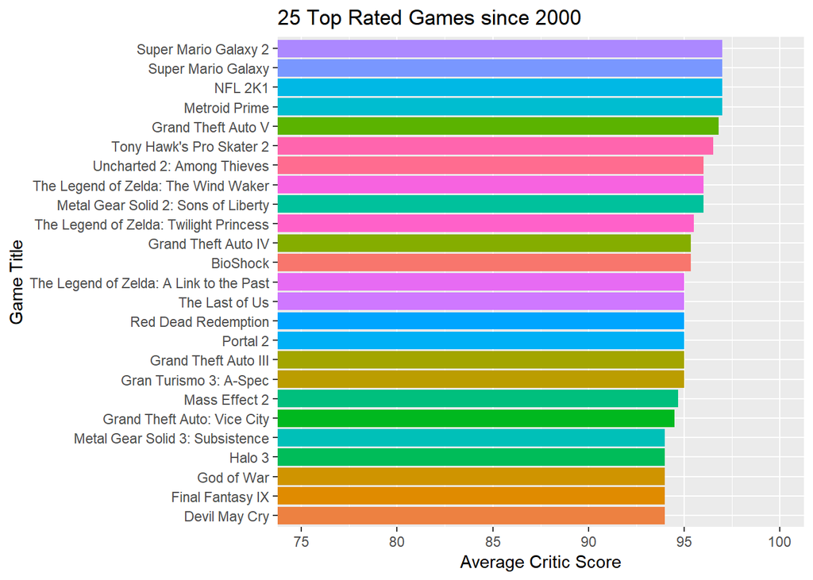

```r
# Now let's look at a bar plot of the top 25 games as rated by critics:
data_ratings %>%
  arrange(desc(avg_critic_rating)) %>%
  slice(1:25) %>%
  ggplot(aes(x=reorder(Name,avg_critic_rating), y=avg_critic_rating, fill=Name)) +
  geom_bar(stat='identity') +
  labs(title="25 Top Rated Games since 2000", x="Game Title", y="Average Critic Score") +
  coord_flip(ylim=c(75,100)) +
  theme(legend.position='none')
```

As you can see, all of the top 25 best rated games by critics had a score over 90/100. This isn’t too surprising, considering that these games are the best of the best. What’s interesting to note is just how many `Zelda` and `Grand Theft Auto` games are in this dataset. It seems that some developers knew what worked for them before, and continued to meet customer expectation with these series of video games.

Since we saw some variation in the games that appear in the top selling games of all time and the top rated games of all time, we will look at which games appear the highest in both sales and ratings. To do this we will assign a rank to each of the games based on their rating. We will do the same for the games based on their sales. We will then take the sum of their two ranks and sort them based on their combined ranks to determine which games are the highest rated and best selling.

```r
# Assigning a rank to the games based on their rating
data_ratings <- data_ratings %>%
  arrange(desc(avg_critic_rating)) %>%
  mutate(Ratings_Rank = row_number())

# Assigning a rank to the games based on their sales
data_sales <- data_sales %>%
  arrange(desc(total_sales)) %>%
  mutate(Sales_Rank = row_number())

# Taking the sum of the ranks and sorting accordingly
data_rankings <- data_ratings %>%
  merge(data_sales, by="Name") %>%
  mutate(Combined_Rank = (Sales_Rank + Ratings_Rank)) %>%
  arrange(Combined_Rank) %>%
  mutate(Combined_Rank = row_number())

# We only want to show the top 25, to ensure it's not too cluttered
data_to_plot <- data_rankings %>%
  slice(1:25)

# Make the graph and display it
figure(title = "Top 25 Games Based on Sales and Ratings", legend_location = NULL) %>%
  ly_points(data = data_to_plot, x = total_sales, y = avg_critic_rating,
            color = Name,
            hover = c(Name, avg_critic_rating, total_sales)) %>%
  x_axis(label = "Total Sales in Million of Units") %>%
  y_axis(label = "Average Critic Rating")
```

[interactive chart not shown]

One thing to note from this data is that games that sell well do not always rank very highly or vice versa. From this we can see that there is a continued trend for Grand Theft Auto games to sell very well and be rating very highly. These games have been coming out for more than a decade and have continued to produce astounding results and push large volumes of sales.

Overall, there’s a lot that we can learn from these graphs and this analysis. We see that overall, critic scores and user scores generally match one another. It’s often thought that they don’t, but it seems that they only don’t match in outlier cases, which is what gets sensationalized in the headlines. We see that most of the best games sold around or over 10 million units, which, assuming an average price of 60 dollars (which isn’t entirely accurate) is 600 million dollars – an insane amount of money.

# Hypothesis Testing

With our analysis out of the way, let’s move on to some hypothesis testing.

Let’s begin hypothesis testing by looking at how or if total sales affects the average critic rating of a game.

```r
LMS <- lm(avg_critic_rating~total_sales, data=data_rankings)

LMS %>%
  tidy()
```

```
## # A tibble: 2 x 5
##   term        estimate std.error statistic  p.value
##   <chr>          <dbl>     <dbl>     <dbl>    <dbl>
## 1 (Intercept)    66.7     0.207      323.  0.
## 2 total_sales     1.27    0.0684      18.6 1.39e-74
```

We can create another linear model to see if there’s a relationship between platforms and a games rating.

```r
data2000 <- data2000 %>%
  mutate(avg_Critic_Score = meanCriticScore)

LMP <- lm(avg_Critic_Score~Platform, data=data2000)

LMP %>%
  tidy()
```

```
## # A tibble: 17 x 5
##    term         estimate std.error statistic  p.value
##    <chr>           <dbl>     <dbl>     <dbl>    <dbl>
##  1 (Intercept)    67.9       0.319   213.    0.
##  2 PlatformDC     19.0       1.59     11.9   1.02e-32
##  3 PlatformDS     -1.12      0.356    -3.14  1.67e- 3
##  4 PlatformGBA     1.23      0.404     3.05  2.28e- 3
##  5 PlatformGC      2.73      0.439     6.23  4.80e-10
##  6 PlatformPC      7.77      0.396    19.6   1.63e-84
##  7 PlatformPS      1.71      0.547     3.13  1.78e- 3
##  8 PlatformPS2     1.11      0.355     3.12  1.80e- 3
##  9 PlatformPS3     2.89      0.377     7.66  1.95e-14
## 10 PlatformPS4     4.32      0.476     9.06  1.42e-19
## 11 PlatformPSP     0.301     0.388     0.775 4.38e- 1
## 12 PlatformPSV     3.35      0.475     7.06  1.73e-12
## 13 PlatformWii    -2.40      0.376    -6.39  1.72e-10
## 14 PlatformWiiU    2.68      0.681     3.94  8.31e- 5
## 15 PlatformX360    0.831     0.377     2.20  2.78e- 2
## 16 PlatformXB      3.27      0.403     8.12  5.11e-16
## 17 PlatformXOne    5.58      0.554    10.1   8.87e-24
```

Looking at this linear model, we can reject the null hypothesis that `Platform` does not have an effect on a games rating.

Now, let’s look create a linear model showing if there is a relationship between genre and rating:

```r
LMG <- lm(avg_Critic_Score~Genre, data=data2000)

LMG %>%
  tidy()
```

```
## # A tibble: 12 x 5
##    term              estimate std.error statistic   p.value
##    <chr>                <dbl>     <dbl>     <dbl>     <dbl>
##  1 (Intercept)         66.8       0.128    523.   0.
##  2 GenreAdventure      -1.30      0.252     -5.15 2.68e-  7
##  3 GenreFighting        2.11      0.312      6.78 1.25e- 11
##  4 GenreMisc            0.589     0.220      2.68 7.42e-  3
##  5 GenrePlatform        3.42      0.295     11.6  5.13e- 31
##  6 GenrePuzzle          4.18      0.372     11.2  3.95e- 29
##  7 GenreRacing          0.928     0.253      3.67 2.41e-  4
##  8 GenreRole-Playing    5.57      0.234     23.8  1.43e-122
##  9 GenreShooter         3.49      0.243     14.4  2.12e- 46
## 10 GenreSimulation      0.767     0.290      2.65 8.04e-  3
## 11 GenreSports          7.03      0.205     34.3  6.00e-247
## 12 GenreStrategy        6.00      0.342     17.6  2.97e- 68
```

Let’s now look at how accurate our linear models’ predictions were. We are going to use the `augment` function to get residual and fitted value data, and create a scatter plot to help visualize this. We will start with our model that looks at rating predicted by sales.

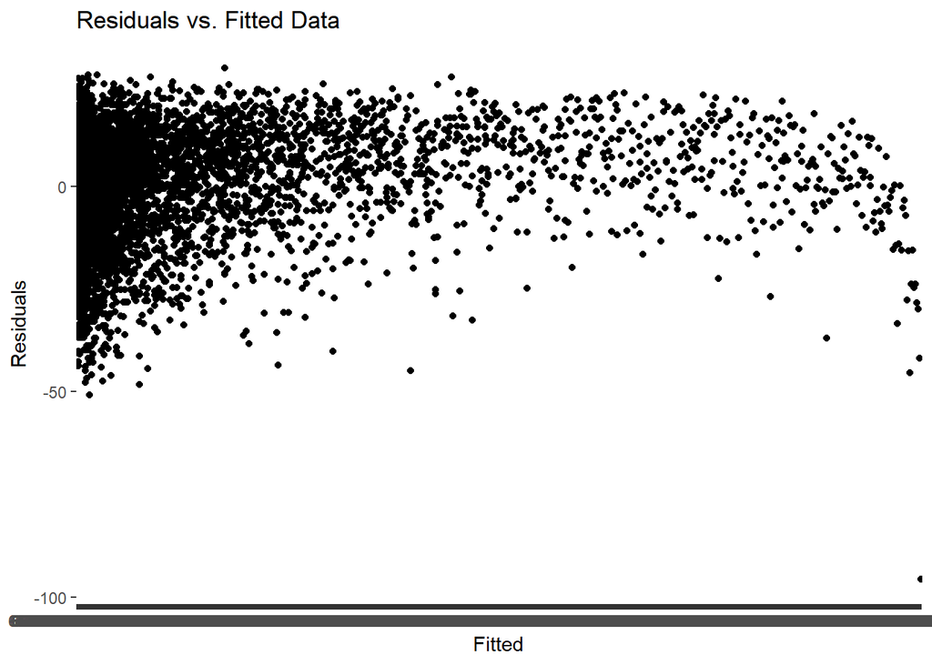

```r
aug_LMS <- augment(LMS)

aug_LMS %>%
  ggplot(aes(x=factor(.fitted), y=.resid)) +
  geom_point() +
  ggtitle("Residuals vs. Fitted Data") +
  xlab("Fitted") +
  ylab("Residuals")
```

Let’s also compare the residuals and fitted values for the linear model that looks at rating predicted by platform:

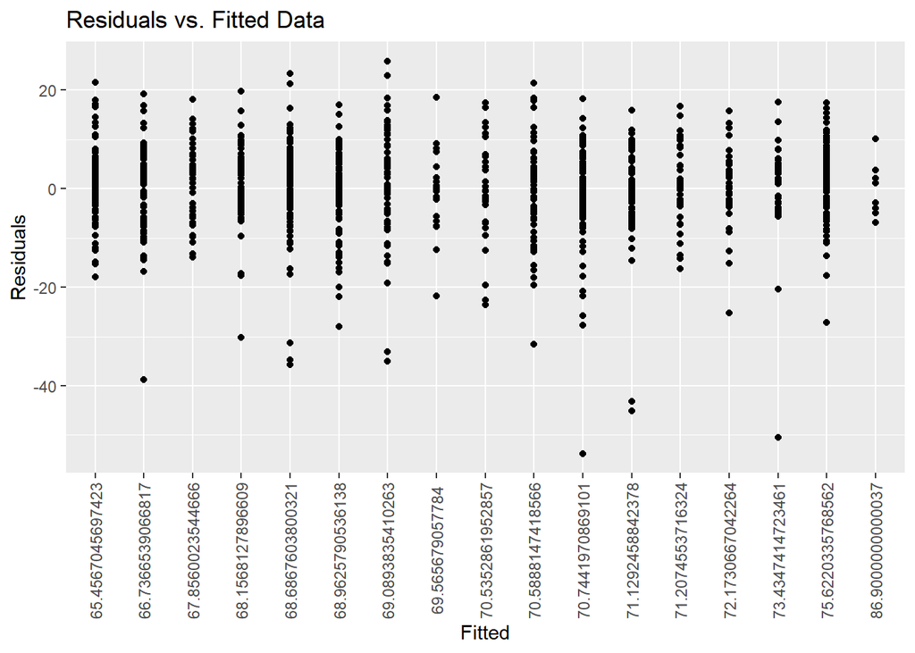

```r
aug_LMP <- augment(LMP)

aug_LMP %>%
  ggplot(aes(x=factor(.fitted), y=.resid)) +
    geom_point() +
    ggtitle("Residuals vs. Fitted Data") +
    xlab("Fitted") +
    ylab("Residuals") +
    theme(axis.text.x = element_text(angle = 90, vjust = 0.5)) # Rotate the x-axis labels to make them easier to read
```

This plot also shows that our model predicting rating by platform is accurate. We can say this because our residuals are centered at zero.

Finally, let’s look at the residuals versus fitted data for our model that looks at rating based on genre:

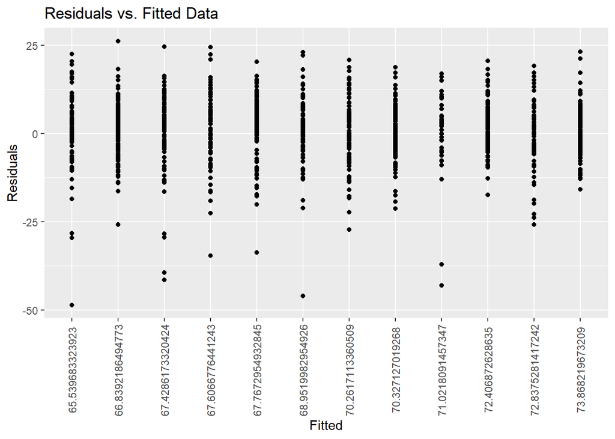

```r
aug_LMG <- augment(LMG)

aug_LMG %>%
  ggplot(aes(x=factor(.fitted), y=.resid)) +
    geom_point() +
    ggtitle("Residuals vs. Fitted Data") +
    xlab("Fitted") +
    ylab("Residuals") +
    theme(axis.text.x = element_text(angle = 90, vjust = 0.5)) # Rotate the x-axis labels to make them easier to read
```

Once again, our residuals are centered at zero. This model appears to be better than our previous model, even! Once again, this plot shows that our model accurately predicts our data.

# Conclusion

This project helped us determine what drives ratings in games.

Developers and publishers can benefit from this kind of analysis by looking closer at this data, thereby determining with better accuracy what games will be rated higher than others.

# Resources

We used a lot of R libraries, so we’ll link some of their documentation as well as some other outside libraries for further reading:

https://www.tidyverse.org/ - All about Tidyverse!

https://hafen.github.io/rbokeh/ - Read more about the rbokeh plotting library here

https://cran.r-project.org/web/packages/ggrepel/vignettes/ggrepel.html - An alternative to rbokeh that we considered! ggrepel works alongside ggplot2.

https://seananderson.ca/2013/10/19/reshape/ - All about reshape2

https://www.rdocumentation.org/packages/broom/versions/0.4.4 - Broom